# Distribution of the enrichment scores

Zuguang Gu ( z.gu@dkfz.de )

2024-12-04

The number of citations from country *A* to country *B* follows a hypergeometric distribution $X \sim \mathrm{Hyper}(m, n, N)$ where $m$ is the total number of times that *B* is cited, $n$ is the total number of times that *A* cites, $N$ is the total number of citations in the globe. To simplify the problem, we use the binomial approximation of the hypergeometric distribution: $X \sim \mathrm{Bi}(p, n)$ where $p = m/N$. The fold enrichment is calculated as

$$r = \frac{k}{k_\mathrm{exp}} = \frac{k}{np}$$

where $k$ is the observed number of citations and $k_\mathrm{exp}$ is the expected number.

Assume the observed $k$ has a offset to the expected $k_\mathrm{exp}$ of $a \cdot \sigma$ where $\sigma$ is the standard deviation of the bimonial distribution and $a$ is the fold factor on $\sigma$, then

$$k = np + a \cdot \sigma = np + a \sqrt{np(1-p)}$$

And we can have the relation between $r$ and $k$ (by cancelling $n$) as:

$$r = \frac{\sqrt{1 + \frac{4k}{a^2(1-p)}} + 1}{\sqrt{1 + \frac{4k}{a^2(1-p)}} - 1} = 1 + \frac{2}{\sqrt{1 + \frac{4k}{a^2(1-p)}} - 1}$$

We can write a function which calculates $\log_2 r$ based on the value of $k$:

```r
f = function(k, a = 1, p = 0.5) {
    r = 1 + 2/(sqrt(1 + 4*k/a^2/(1-p)) - 1)
    log2(r)
}
```

We then demonstrate the relation between $\log_2 r$ and $k$ by a simple simulation. We generate a list of random $k$ from the binomial distribution where the size $n$ is also randomly generated where $\log_{10} n$ is from a uniform distribution in the internal $[3, 7]$.

```r
set.seed(123)
p = 0.1
size = round(10^(runif(10000, min = 3, max = 7)))
k = sapply(size, function(x) rbinom(1, x, p))
```

We plot $\log_2 r$ against $k$, also their theoretical relations (with 1/2/3 offsets of $\sigma$ to the expected value):

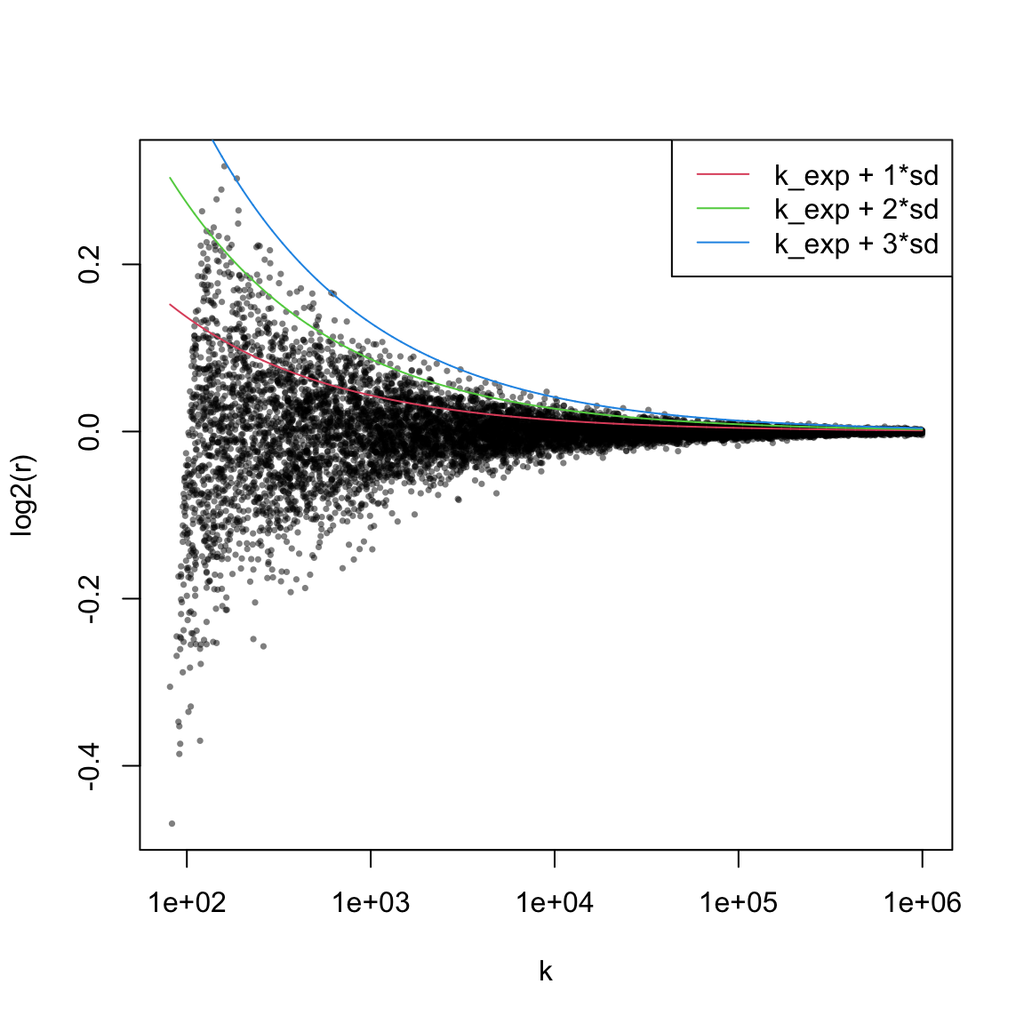

```r
plot(k, log2(k/(size*p)), log = "x", pch = 16, cex = 0.5, col = "#00000080", ylab = "log2(r)")

od = order(k)
lines(k[od], f(k[od], a = 1, p = p), col = 2)
lines(k[od], f(k[od], a = 2, p = p), col = 3)
lines(k[od], f(k[od], a = 3, p = p), col = 4)

legend("topright", legend = c("k_exp + 1*sd", "k_exp + 2*sd", "k_exp + 3*sd"), lty = 1, col = 2:4)
```

So here we can see the range of the log2 fold enrichment (when the enrichment is positive) decreases when the number of citations increases.